# FECR - Use examples

In this page we show of to perform FECR tests - Fecal Egg Count Reduction tests - from individual values of EPG: egg per gram of feces/fecal sediment.

Implemented methods refer to Cabaret & Berrag (2004), as well as our method that improve their proposed best approach.

We demonstrate the use of these methods on simulated data, as well as the toy example presented in this reference article.

# Use example on simulated data

## EPG simulation

We simulate EPG values (one per individual) by drawing from poisson distributions as follow:

```r
library(FECR)

set.seed(42)

# Generate random EPG values, in the simple case of equal sample size
T1 <- rpois(50,100);T1.mean <- mean(T1)
T2 <- rpois(50,10);T2.mean <- mean(T2)
C1 <- rpois(50,100);C1.mean <- mean(C1)
C2 <- rpois(50,90);C2.mean <- mean(C2)
```

## FECR calculations

### When sample size is the same

The `FECR()` function of this `FECR` package takes vectors of EPG values as arguments `T1`, `T2`, `C1`, and `C2`.

From these values, you can specify a method between `"Kochapakdee"`, `"Dash"`, `"Coles"`, `"Cabaret1"`, `"Cabaret2"`.

Note that some of these methods do not require all arguments: for these methods, you will need to specify what EPG values are inputted through named arguments (e.g. `T2 = your.vector`), otherwise an error message will be displayed.

The logical argument `compute.CI` allows for the computation of a confidence interval (95% by default) for individual-based methods (cf. Cabaret & Berrag, 2004)

```r
# Calculation of FECR values according to different methods
FECR(T1.mean,T2.mean,method = "Kochapakdee")
```

```
## [1] 89.97253
```

```r
FECR(T1,T2,C1,C2,method = "Dash")
```

```
## [1] 88.83641
```

```r
FECR(T2 = T2.mean,C2 = C2.mean,method = "Coles")
```

```
## [1] 88.55799
```

```r
FECR(T2 = T2,C2 = C2,method = "Coles")
```

```
## [1] 88.55799
```

```r
FECR(T1,T2,method = "Cabaret1")
```

```
## [1] 89.89805
```

```r
FECR(T1,T2,C1,C2,method = "Cabaret2")
```

```
## [1] 88.602
```

```r
FECR(T1,T2,C1,C2,method = "Cabaret2",compute.CI = TRUE)
```

```
## [1] 88.602
## attr(,"CI")
##     2.5%    97.5%
## 87.35018 89.75919
```

```r
FECR(T1,T2,C1,C2,method = "MacIntosh",compute.CI = TRUE)
```

```
## [1] 88.61238
## attr(,"CI")
##     2.5%    97.5%
## 88.44445 88.76411
```

### When sample size is uneven

The last included method, `"MacIntosh"`, is an improvement of the `"Cabaret2"` that:

- depends on the arbitrary pair-matchings of individuals in the control (C) and test (T) groups
- cannot be applied to unequal sample-sizes without arbitrarily subset the larger group

```r
# Generate random EPG values, in the case of unequal sample size
T1 <- rpois(60,100);T1.mean<- mean(T1)
T2 <- rpois(60,10);T2.mean<- mean(T2)
C1 <- rpois(50,100);C1.mean<- mean(C1)
C2 <- rpois(50,90);C2.mean<- mean(C2)

# Calculation of FECR values according to our sample-size unsensitive method
FECR(T1,T2,C1,C2,method = "Cabaret2",compute.CI = TRUE)
```

```
## Error in check_if_valid_parameters(arg.list): Some of T1,T2,C1,C2 are not of the same length.
```

```r
FECR(T1,T2,C1,C2,method = "MacIntosh")
```

```
## [1] 87.46709
```

```r
FECR(T1,T2,C1,C2,method = "MacIntosh",compute.CI = TRUE)
```

```
## [1] 87.46709
## attr(,"CI")
##     2.5%    97.5%
## 87.28565 87.64213
```

# Why improve the method from Cabaret & Berrag (2004)?

The motivation that led us to propose an improvement over the individual method proposed by the authors is that we identified the two pitfalls mentioned in the previous paragraph, i.e. the arbitrary pair-matching and requirement of an even sample-size.

Hereafter, we demonstrate the issue from the paper’s own toy example.

## EPG values import

```r
# Generate random EPG values, in the simple case of equal sample size
T1 <- c(450,1250,1700,900,2550,500,750,850,500)
T1.mean <- mean(T1)
T2 <- c(50,0,0,0,50,450,400,0,0)
T2.mean <- mean(T2)
C1 <- c(750,600,500,700,1000,700,300,1250,1050)
C1.mean <- mean(C1)
C2 <- c(540,400,1000,1750,350,600,900,550,450)
C2.mean <- mean(C2)
```

## FECR calculations

As expected, we find FECR values similar to what the authors report:

```r
# Generate random EPG values, in the simple case of equal sample size
FECR(T1.mean,T2.mean,method = "Kochapakdee")            # 90% in the original paper
```

```
## [1] 89.94709
```

```r
FECR(T1,T2,C1,C2,method = "Dash")                       # 90% in the original paper
```

```
## [1] 89.47058
```

```r
FECR(T2 = T2.mean,C2 = C2.mean,method = "Coles")        # 86% in the original paper
```

```
## [1] 85.47401
```

```r
FECR(T1,T2,method = "Cabaret1",compute.CI = TRUE)       # 83%(58-99%) in the original paper
```

```
## [1] 82.62164
## attr(,"CI")
##  lower.2.5% upper.97.5%
##    61.99437    99.12854
```

```r
FECR(T1,T2,C1,C2,method = "Cabaret2",compute.CI = TRUE) # 84%(51-97%) in the original paper
```

```
## [1] 84.02088
## attr(,"CI")
##     2.5%    97.5%
## 60.68754 98.28532
```

```r
FECR(T1,T2,C1,C2,method = "MacIntosh",compute.CI = TRUE)
```

```
## [1] 75.37662
## attr(,"CI")
##     2.5%    97.5%
## 63.20409 85.82464
```

Our proposed method leads to a somewhat comparable value, albeit significantly lowered. We explain more on this hereafter.

## Demonstration of the pit-falls

### The implicit arbitrary pair-matching

The toy-example’s values only lead to the reported FECR when inputted in their specific order. Shuffling this order is enough to change the FECR value:

```r
set.seed(1000)
# shuffling T and C
new.T <- sample(1:length(T1))
new.C <- sample(1:length(C1))

T1.new <- T1[new.T]
T2.new <- T2[new.T]
C1.new <- C1[new.C]
C2.new <- C2[new.C]

# Recalculating FECRs
FECR(T1.new,T2.new,C1.new,C2.new,method = "Cabaret2",compute.CI = TRUE)
```

```
## [1] 61.27418
## attr(,"CI")
##     2.5%    97.5%
## 12.75385 98.14815
```

```r
FECR(T1.new,T2.new,C1.new,C2.new,method = "MacIntosh",compute.CI = TRUE)
```

```
## [1] 75.37662
## attr(,"CI")
##     2.5%    97.5%
## 63.23173 85.67652
```

Note that shuffling obviously has not change EPG distribution in T and C groups:

```r
summary(T1)
```

```
##    Min. 1st Qu.  Median    Mean 3rd Qu.    Max.
##     450     500     850    1050    1250    2550
```

```r
summary(T1.new)
```

```
##    Min. 1st Qu.  Median    Mean 3rd Qu.    Max.
##     450     500     850    1050    1250    2550
```

```r
summary(C2)
```

```
##    Min. 1st Qu.  Median    Mean 3rd Qu.    Max.
##   350.0   450.0   550.0   726.7   900.0  1750.0
```

```r
summary(C2.new)
```

```
##    Min. 1st Qu.  Median    Mean 3rd Qu.    Max.
##   350.0   450.0   550.0   726.7   900.0  1750.0
```

And neither have methods based on group-averaged EPG

```r
FECR(T1.new,T2.new,C1.new,C2.new,method = "Dash")                       # 90% in the original paper
```

```
## [1] 89.47058
```

```r
FECR(T2 = T2.new,C2 = C2.new,method = "Coles")        # 86% in the original paper
```

```
## [1] 85.47401
```

More precisely, here is the bootstrapped distribution of the FECR value itself (not its confidence interval), across several reshuffling:

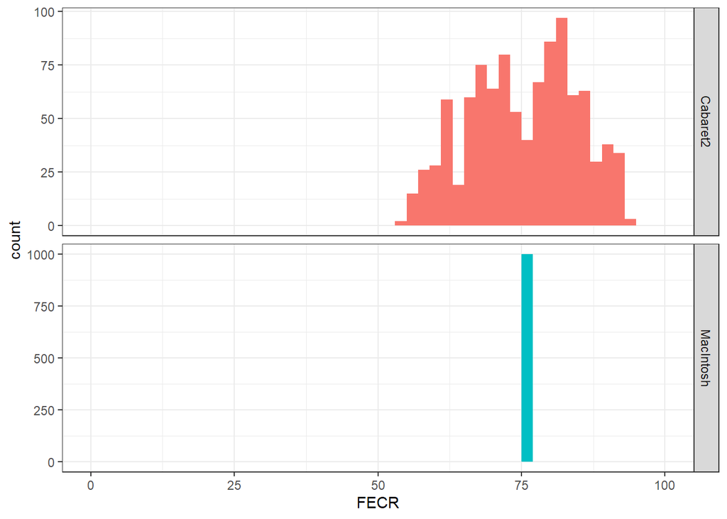

```r
library(ggplot2)
library(magrittr)

set.seed(9000)

# replicating the shuffling of T and C
FECR.shuffled <- replicate(
  n = 1000,
  simplify = FALSE,
  expr = {
    # shuffle
    new.T <- sample(1:length(T1))
    new.C <- sample(1:length(C1))

    T1.new <- T1[new.T]
    T2.new <- T2[new.T]
    C1.new <- C1[new.C]
    C2.new <- C2[new.C]

    #FECR calculations
    data.frame(
      method = c("Cabaret2","MacIntosh"),
      FECR = c(
        FECR(T1.new,T2.new,C1.new,C2.new,method = "Cabaret2",compute.CI = FALSE),
        FECR(T1.new,T2.new,C1.new,C2.new,method = "MacIntosh",compute.CI = FALSE)
      )
    )
  }
) %>%
  do.call(rbind,.)
FECR.shuffled %>%
  ggplot(aes(x = FECR,fill = method))+
  facet_grid(method~.,scales = "free")+
  geom_histogram(binwidth = 2,alpha = 80)+
  guides(fill = "none")+
  scale_x_continuous(limits = c(0,100))+
  theme_bw()
```

Our method consistently leads to a single FECR value, close to the mean of this distribution:

```r
subset(FECR.shuffled,method == "MacIntosh") %>% .$FECR %>%  unique()
```

```
## [1] 75.37662
```

```r
subset(FECR.shuffled,method == "Cabaret2") %>% .$FECR %>%  mean()
```

```
## [1] 75.30635
```

### Uneven sample sizes

Let’s simulate upon this toy example an uneven sample size between the T and C groups by randomly removing 2 individuals from one, e.g. T.

Since the `"Cabaret2"` method relies on a summation across n individuals in both the T and C groups, this requires subsetting the larger group too by randomly removing 2 individuals. This isn’t a requirement for our method, which will keep using all the individuals from C despite T having 2 individuals less.

```r
set.seed(9999)
# removing 2 individuals from T and C
new.T <- sample(1:length(T1),length(T1) - 2)
new.C <- sample(1:length(C1),length(C1) - 2)

T1.new <- T1[new.T]
T2.new <- T2[new.T]
C1.new <- C1[new.C]
C2.new <- C2[new.C]

# Recalculating FECRs
FECR(T1.new,T2.new,C1.new,C2.new,method = "Cabaret2",compute.CI = TRUE)
```

```
## [1] 69.59653
## attr(,"CI")
##     2.5%    97.5%
## 11.15497 99.47090
```

```r
FECR(T1.new,T2.new,C1,C2,method = "Cabaret2",compute.CI = TRUE)
```

```
## Error in check_if_valid_parameters(arg.list): Some of T1,T2,C1,C2 are not of the same length.
```

```r
FECR(T1.new,T2.new,C1,C2,method = "MacIntosh",compute.CI = TRUE)
```

```
## [1] 79.13679
## attr(,"CI")
##     2.5%    97.5%
## 64.90151 91.34628
```

Again, if this is replicated many times, FECRs are impacted differently across the two methods:

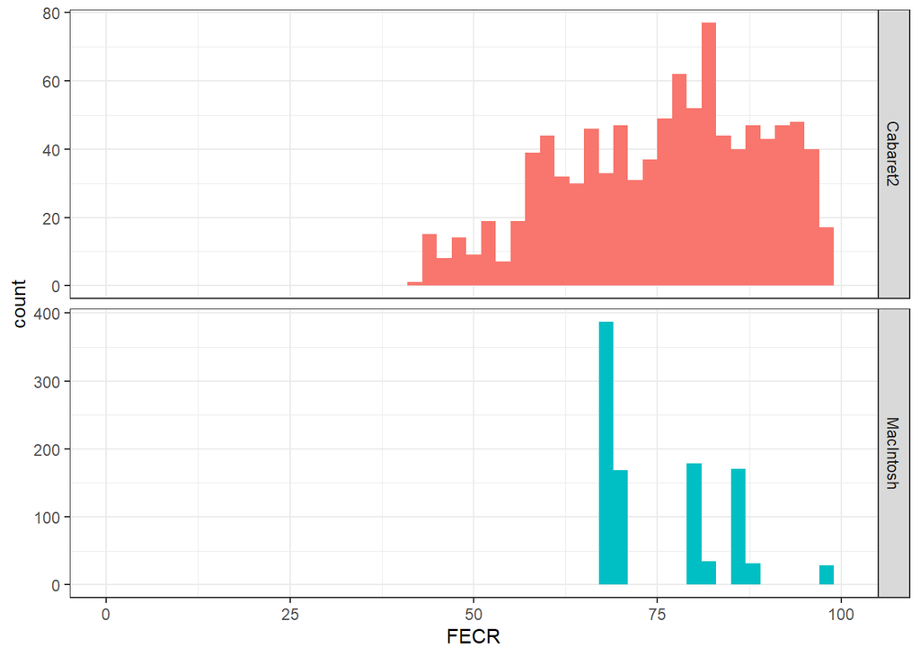

```r
set.seed(777)

# replicating the shuffling of T and C
FECR.minus.2 <- replicate(
  n = 1000,
  simplify = FALSE,
  expr = {
    # shuffle
    new.T <- sample(1:length(T1),length(T1) - 2)
    new.C <- sample(1:length(C1),length(C1) - 2)

    T1.new <- T1[new.T]
    T2.new <- T2[new.T]
    C1.new <- C1[new.C]
    C2.new <- C2[new.C]

    #FECR calculations
    data.frame(
      method = c("Cabaret2","MacIntosh"),
      FECR = c(
        FECR(T1.new,T2.new,C1.new,C2.new,method = "Cabaret2",compute.CI = FALSE),
        FECR(T1.new,T2.new,C1,C2,method = "MacIntosh",compute.CI = FALSE)
      )
    )
  }
) %>%
  do.call(rbind,.)
FECR.minus.2 %>%
  ggplot(aes(x = FECR,fill = method))+
  facet_grid(method~.,scales = "free")+
  geom_histogram(binwidth = 2,alpha = 80)+
  guides(fill = "none")+
  scale_x_continuous(limits = c(0,100))+
  theme_bw()
```

Therefore, on top of using all the data available, our method also leads to more stable FECR values.

### What about confidence intervals?

The same processes of reshuffling or removing datapoints can be replicated to calculate the stability of confidence intervals’ boundaries:

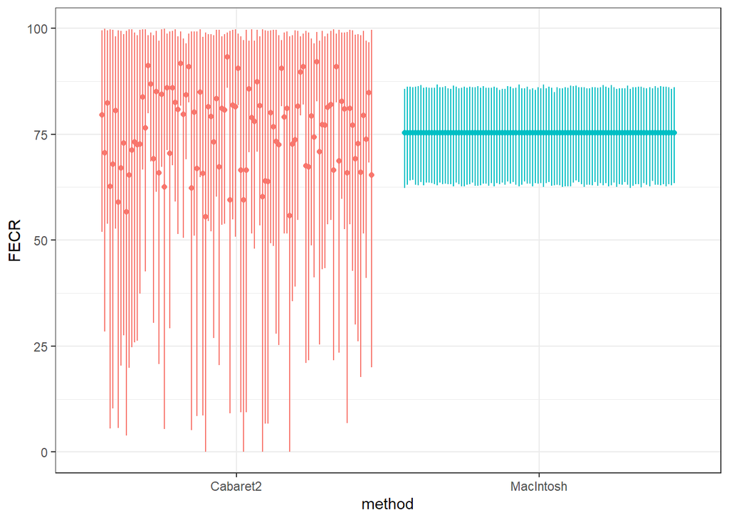

```r
set.seed(1234)

# replicating the shuffling of T and C
CI.shuffled <- replicate(
  n = 100,
  simplify = FALSE,
  expr = {
    # shuffle
    new.T <- sample(1:length(T1))
    new.C <- sample(1:length(C1))

    T1.new <- T1[new.T]
    T2.new <- T2[new.T]
    C1.new <- C1[new.C]
    C2.new <- C2[new.C]
    Cab <- FECR(T1.new,T2.new,C1.new,C2.new,method = "Cabaret2",
                          compute.CI = TRUE,pb = FALSE)
    Mac <- FECR(T1.new,T2.new,C1.new,C2.new,method = "MacIntosh",
                          compute.CI = TRUE,pb = FALSE)

    #FECR calculations
    data.frame(
      method = c("Cabaret2","MacIntosh"),
      FECR = c(Cab,Mac),
      lower = c(
        attr(Cab,"CI")[1],
        attr(Mac,"CI")[1]
      ),
      upper = c(
        attr(Cab,"CI")[2],
        attr(Mac,"CI")[2]
      )
    )
  }
) %>%
  do.call(rbind,.) %>%
  cbind(rep = factor(rep(1:100,each = 2)),.)
CI.shuffled %>%
  ggplot(aes(method,FECR,colour = method,group = rep))+
  geom_linerange(aes(ymin = lower,ymax = upper),position = position_dodge(.9))+
  geom_point(position = position_dodge(.9))+
  guides(colour = "none")+
  theme_bw()
```

Our proposed method is designed to calculate a FECR value (and its confidence interval) that is unique for a given set of EPG values in T and C groups. The only slight variations observed regarding the boundaries of the confidence interval is attributable to the bootstrap’s own random resampling.